# Reproducible Research - Peer Assessment 1

Wen Hao Wong

### A. Loading and preprocessing data

1. Loading the data

```r
data <- read.csv("activity.csv", header = TRUE)
summary(data)
```

```
##      steps                date          interval
##  Min.   :  0.00   2012-10-01:  288   Min.   :   0.0
##  1st Qu.:  0.00   2012-10-02:  288   1st Qu.: 588.8
##  Median :  0.00   2012-10-03:  288   Median :1177.5
##  Mean   : 37.38   2012-10-04:  288   Mean   :1177.5
##  3rd Qu.: 12.00   2012-10-05:  288   3rd Qu.:1766.2
##  Max.   :806.00   2012-10-06:  288   Max.   :2355.0
##  NA's   :2304     (Other)   :15840
```

```r
str(data)
```

```
## 'data.frame':    17568 obs. of  3 variables:
##  $ steps   : int  NA NA NA NA NA NA NA NA NA NA ...
##  $ date    : Factor w/ 61 levels "2012-10-01","2012-10-02",..: 1 1 1 1 1 1 1 1 1 1 ...
##  $ interval: int  0 5 10 15 20 25 30 35 40 45 ...
```

```r
head(data)
```

```
##   steps       date interval
## 1    NA 2012-10-01        0
## 2    NA 2012-10-01        5
## 3    NA 2012-10-01       10
## 4    NA 2012-10-01       15
## 5    NA 2012-10-01       20
## 6    NA 2012-10-01       25
```

```r
tail(data)
```

```
##       steps       date interval
## 17563    NA 2012-11-30     2330
## 17564    NA 2012-11-30     2335
## 17565    NA 2012-11-30     2340
## 17566    NA 2012-11-30     2345
## 17567    NA 2012-11-30     2350
## 17568    NA 2012-11-30     2355
```

2. Through looking at the summary and structure of the data, as well as examining some rows of the dataset, it appears that no further processing/transformation is necessary at this point in time.

### B. What is mean total number of steps taken per day?

1. Making a histogram of the total number of steps taken each day

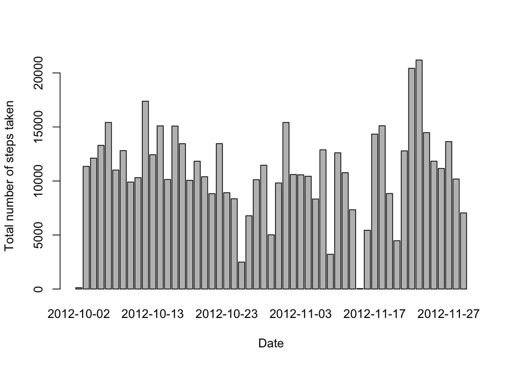

```r
steps_day <- aggregate(steps ~ date, data = data, FUN = sum)
barplot(steps_day$steps, ylab = "Total number of steps taken", xlab = "Date", names.arg = steps_day$date)
```

2. The **mean** and **median** total number of steps taken each day are as follows:

```r
mean(steps_day$steps)
```

```
## [1] 10766.19
```

```r
median(steps_day$steps)
```

```
## [1] 10765
```

### C. What is the average daily activity pattern?

1. Making a time series plot of the 5-minute interval (x-axis) and the average number of steps taken, averaged across all days (y-axis)

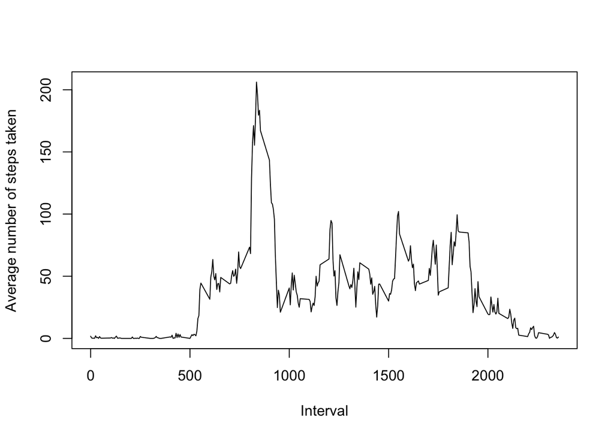

```r
steps_interval <- aggregate(steps ~ interval, data = data, FUN = mean)
plot(steps_interval, type = "l", ylab = "Average number of steps taken", xlab = "Interval")
```

2. The 5-min interval that contains the maximum number of steps is as follows:

```r
steps_interval$interval[which.max(steps_interval$steps)]
```

```
## [1] 835
```

### D. Imputing missing values

1. The total number of missing values in the dataset is as follows:

```r
sum(is.na(data))
```

```
## [1] 2304
```

2. My strategy is to use the means of the 5-minute intervals as fillers for the missing values.
3. Using this strategy, I create a new dataset but with the mising data filled:

```r
data_merged <- merge(data, steps_interval, by = "interval", suffixes = c("",".y"))
nas <- is.na(data_merged$steps)
data_merged$steps[nas] <- data_merged$steps.y[nas]
data_filled <- data_merged[, c(1:3)]
```

4. I then make a histogram of the total number of steps taken each day. The **mean** is the same but the **median** is (a little) different. The impact of imptung mising values seems to be small.

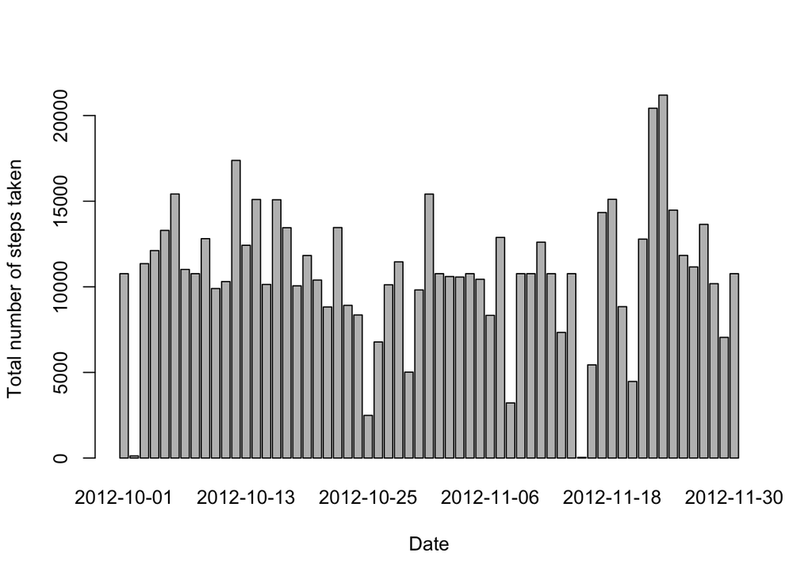

```r
steps_day_filled <- aggregate(steps ~ date, data = data_filled, FUN = sum)
barplot(steps_day_filled$steps, ylab = "Total number of steps taken", xlab = "Date", names.arg = steps_day_filled$date)
```

```r
mean(steps_day_filled$steps)
```

```
## [1] 10766.19
```

```r
median(steps_day_filled$steps)
```

```
## [1] 10766.19
```

### E. Are there differences in activity patterns between weekdays and weekends?

```r
daytype <- function(date) {
    if (weekdays(as.Date(date)) %in% c("Saturday", "Sunday")) {
        "weekend"
    } else {
        "weekday"
    }
}
data_filled$daytype <- as.factor(sapply(data_filled$date, daytype))
```

2. Making a panel plot containing a time series plot of the 5-minute interval (x-axis) and the average number of steps taken, averaged across all weekday days or weekend days (y-axis):

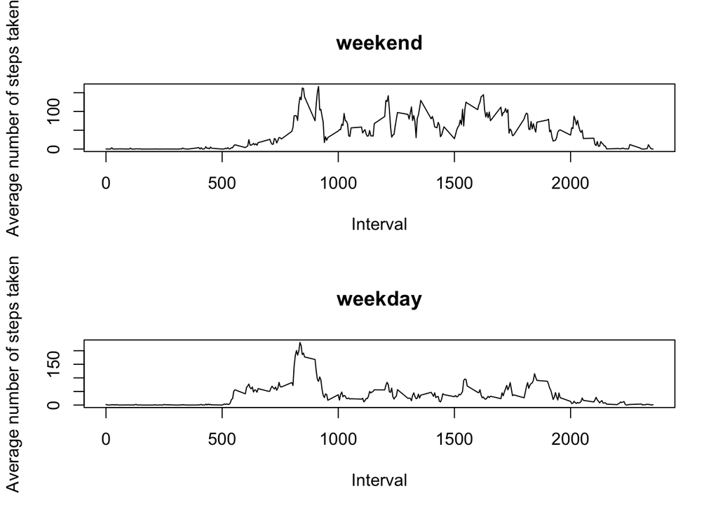

```r
par(mfrow = c(2,1))
for (type in c("weekend", "weekday")) {
    steps_interval_filled_type <- aggregate(steps ~ interval, data = data_filled, subset = data_filled$daytype==type, FUN = mean)
    plot(steps_interval_filled_type, type = "l", main = type, ylab = "Average number of steps taken", xlab = "Interval")
}
```